# STA 601/360 Homework5

Jae Hyun Lee, jl914

01 October, 2019

# HW5 for STA-601

## Exercise 1

Given {$\bar{y_A} = 75.2, s_A = 7.3$}, {$\bar{y_A} = 77.5, s_B = 8.1$} with conjugate prior $\mu_0 = 75, \sigma_0^2 = 100$. For each {(1,1)(2,2)(4,4)(8,8)(16,16),(32,32)} obtain $p(\theta_A < \theta_B \mid y_A,y_B)$ via Monte carlo sampling. Plot this probability as a function of $(k_0,v_0)$. Describe how you might use this plot to convey the evidence that $\theta_A < \theta_B$ to people of a variety of prior opinions

$$When \; y_1 \cdot\cdot\cdot y_n \sim iid\; N(\theta,\sigma^2), \quad p(y_1 \cdot\cdot\cdot y_n \mid \theta,\sigma^2) = (2\pi)^{-2/n}(\sigma^2)^{-2/n}exp\{-\frac{\sum(y_i -\theta)^2}{\sigma^2}\}$$

$$When \; \theta\mid\sigma^2 \sim N(\mu_0,\frac{\sigma_0^2}{k_0}), \quad p(\theta\mid\sigma^{2}) = (2\pi)^{-1/2} (\frac{\sigma^2}{k_0})^{-1/2}exp\{-\frac{k_0(\theta-\mu_0)^2}{2\sigma^2}\}$$

$$\begin{aligned}
Let \; 1/\sigma^2 \; be \; \lambda \\ \\
p(\theta \mid y_1 \cdot\cdot\cdot y_n,\lambda) &\propto p(\theta\mid\lambda)p(y_1 \cdot\cdot\cdot y_n \mid \theta, \lambda) \\
&\propto exp\{-\frac{\lambda}{2}(n\theta^2 -2\sum y_i \theta + k_0\theta^2 -2k_0\mu_0) \} \\
&= exp\{-\frac{\lambda(k_0+n)}{2}[\theta^2 - \frac{2}{k_0+n}(n\bar{y}+k_0\mu_0)] \} \\
&\propto exp\{-\frac{\lambda(k_0+n)}{2}[\theta^ - \frac{1}{k_0+n}(n\bar{y}+k_0\mu_0)]^2 \}\\
&\rightarrow \theta \mid y_1 \cdot\cdot\cdot y_n, \lambda \sim N(\frac{n\bar{y}+k_0\mu_0}{k_0 +n},1/\lambda(k_0+n))
\end{aligned}$$

$$\begin{aligned}
\lambda \sim gamma(\frac{v_0}{2}, \frac{v_0\sigma_0^2}{2}), \; Then\\ \\
p(\lambda\mid y_1 \cdot\cdot\cdot y_n) &\propto p(\lambda)\int p(y_1 \cdot\cdot\cdot y_n \mid \lambda,\theta)p(\theta\mid\lambda)d\theta \\
&\propto \lambda^{v_0/2 -1}exp\{-\lambda(v_0\sigma_0^2)/2\} \times \lambda^{n/2}exp\{-\frac{\lambda}{2}((n-1)S^2 + \frac{nk_0}{k_n}(\bar{y} - \mu_0 )^2) \} \\
&\propto \lambda^{\frac{v_0+n}{2}-1}exp\{-\frac{\lambda}{2}[v_0\sigma^2 + (n-1)S^2 + \frac{nk_0}{k_n}(\bar{y} - \mu_0)^2] \} \\
&\rightarrow \lambda \sim gamma((v_0 + n)/2,[v_0\sigma^2 + (n-1)S^2 + \frac{nk_0}{k_n}(\bar{y} - \mu_0)^2]/2)
\end{aligned}$$

Thus

#### a)

```r
n <- 16
mu0 <- 75
sigma0 <- 100
k0 <- 2^seq(0,8,1)
v0 <- k0
stat <- data.frame(matrix(c(75.2,77.5,7.3,8.1),nrow=2))
colnames(stat) <- c("mean","sd")
kn <- k0 + n
vn <- v0 + n
theta_A <- matrix(rep(NA,length(k0)*10000),nrow = 10000)
theta_B <- matrix(rep(NA,length(k0)*10000),nrow = 10000)
```

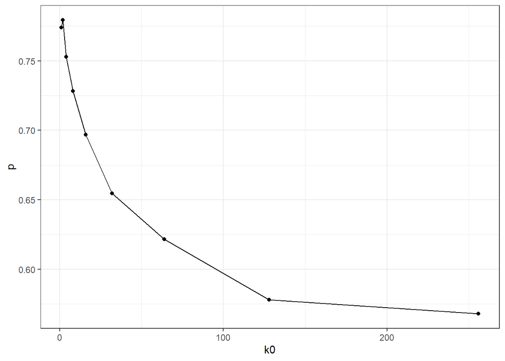

```r
set.seed(1000)
for(i in 1:length(k0)){
  for(j in 1:10000){
    prec_A <- rgamma(1, vn[i]/2, ((v0[i]*sigma0 + (n-1)*stat$sd[1]^2 + n*  v0[i]/vn[i]*(stat$mean[1] - mu0)^2)/2))
    sigma_A <- 1/prec_A
    theta_A[j,i] <- rnorm(1,(n * stat$mean[1] + k0[i] * mu0)/kn[i], sqrt(sigma_A/kn[i]))

    prec_B <- rgamma(1,vn[i]/2, ((v0[i]*sigma0 + (n-1)*stat$sd[2]^2 + n*  v0[i]/vn[i]*(stat$mean[2] - mu0)^2)/2))
    sigma_B <- 1/prec_B
    theta_B[j,i] <- rnorm(1,(n * stat$mean[2] + k0[i] * mu0)/kn[i], sqrt(sigma_B/kn[i]))
  }
}
p <- rep(NA,length(k0))
for(i in 1:length(k0)){
  p[i] <- mean(theta_A[,i]<theta_B[,i])
}
result <- data.frame(cbind(k0,p))
ggplot(result, mapping = aes(x= k0, y=p)) +
  geom_line() +
  geom_point()
```

```r
  labs(title = "p(theta_B > theta_A) vs k0")
```

```
## $title
## [1] "p(theta_B > theta_A) vs k0"
##
## attr(,"class")
## [1] "labels"
```

When prior sample size $k_0 = v_0$ is small, observations which support $\theta_B>\theta_A$ dominate posterior distribution which means prior information have less credibility. As a result when $k_0$ is small, probability $\theta_B>\theta_A$ is very large. But as prior sample size grow, we can see that probability $\theta_B>\theta_A$ decreases which means that prior information which support idea that their mean is same have more credibility than before as prior sample size gets bigger.

#### b)

```r
set.seed(1000)
n <- 16
k0 <- 2^seq(0,8,1)
p2 <- rep(NA,length(k0))
y_A <- y_B <- 10
while(!(near(mean(y_A),75.2,tol = 0.1) & near(sd(y_A),7.3,tol = 0.1))){
  y_A <- rnorm(n = n, 75.2, 7.3)
}
while(!(near(mean(y_B),77.5,tol = 0.1) & near(sd(y_B),8.1,tol = 0.1))){
  y_B <- rnorm(n = n, 77.5, 8.1)
}
c(mean(y_A),mean(y_B))
```

```
## [1] 75.16864 77.47323
```

```r
c(sd(y_A),sd(y_B))
```

```
## [1] 7.386313 8.118901
```

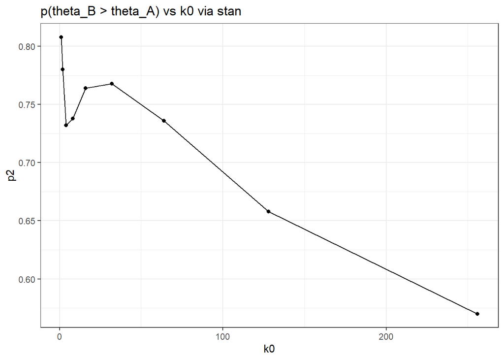

```r
mystan <- rstan::stan_model("hmc_norm_example.stan")
for(i in 1:length(k0)){
  stan_res_A <- rstan::sampling(mystan, data = list(X = y_A,
                                                             N = n,
                                                             Sigma = 7.3, K = k0[i]),
                        chains = 1, iter = 600, warmup = 100, verbose = F, refresh = 0) %>%
            rstan::extract()
  stan_res_B <- rstan::sampling(mystan, data = list(X = y_B,
                                                             N = n,
                                                             Sigma =8.1, K = k0[i]),
                        chains = 1, iter = 600, warmup = 100, verbose = F, refresh = 0) %>%
            rstan::extract()

  p2[i] <- mean(stan_res_A$theta < stan_res_B$theta)
}
result <- data.frame(cbind(k0,p2))
ggplot(result, mapping = aes(x= k0, y=p2)) +
  geom_line() +
  geom_point() +
  labs(title = "p(theta_B > theta_A) vs k0 via stan")
```

## Exercise2

The Jeffreys joint prior for the normal ($\theta$ and $\sigma^2$) is given by
$$p_J(\theta,1/\sigma^2)\propto (\sigma^{-2})^{3/2}.$$
Let precision parameter be $\lambda = 1/\sigma^2$. Then $p(\theta,\lambda) \propto \lambda^{2/3}$ and $\int p(\theta,\lambda)d\theta=p(\lambda) \propto \lambda^{2/3}$. That is $p(\theta \mid \lambda) \propto 1$

$$\begin{aligned}
p(y_1 \cdot\cdot\cdot y_n \mid \theta,\lambda) &= \prod_{i=1}^{n} (2\pi)^{-1/2} \lambda^{1/2}exp\{-\frac{\lambda(y_i-\theta)^2}{2}\} \\
&\propto \lambda^{n/2}exp\{-\frac{\lambda\sum(y_i-\theta)^2}{2}\}
\end{aligned}$$

$$\begin{aligned}
p(\theta,\lambda \mid y_1 \cdot\cdot\cdot y_n) &\propto p(\theta,\lambda)p(y_1 \cdot\cdot\cdot y_n \mid \theta,\lambda) \\
&\propto \lambda^{3/2} \times \lambda^{n/2}exp\{-\frac{\lambda \sum(y_i - \theta)^2}{2} \} \\
&= \lambda^{\frac{3+n}{2}}exp\{-\frac{\lambda}{2}(\sum y_i^2 -2\theta\sum y_i + n\theta^2)\} \\
&= \lambda^{\frac{3+n}{2}}exp\{-\frac{n\lambda}{2}(\theta^2 -2\bar{y}\theta + \bar{y}^2) + \frac{\lambda n \bar{y}}{2} -\frac{\lambda\sum y_i^2}{2} \} \\
&= \lambda^{\frac{3+n}{2}}exp\{-\frac{\lambda}{2}(\sum y_i^2 - n\bar{y}^2)\}exp\{-\frac{n\lambda}{2}(\theta - \bar{y})^2\} \\
&= \underbrace{\lambda^{\frac{3+n}{2}}exp\{-\frac{\lambda}{2}\sum(y_i - \bar{y})^2\}}_{kernal \; of \; gamma} \underbrace{exp\{-\frac{n\lambda}{2}(\theta - \bar{y})^2\}}_{kernal \; of \; normal }
\end{aligned}$$
We can factorize above equation. Thus we can conclude that
$$\begin{aligned}
p(\theta \mid \lambda, y_1 \cdot\cdot\cdot y_n) \sim N(\bar{y}, \frac{\sigma^2}{n}) \\
p(\lambda \mid y_1 \cdot\cdot\cdot y_n) \sim gamma(\frac{5+n}{2},\frac{\sum(y_i - \bar{y})^2}{2})
\end{aligned}$$
As a result, we can know that posterior distribution is proper because
$$\int\int p(\theta,\lambda \mid y_1 \cdot\cdot\cdot y_n)d\theta d\lambda \propto \int \lambda^{\frac{3+n}{2}}exp\{-\frac{\lambda}{2}\sum(y_i - \bar{y})^2\} d\lambda \propto 1$$